# 2018 Bay Wheels Ride Data Exploration and Visualization

### by Ayush Ranjan

## Overview:

> Bay Wheels (previously known as Ford GoBike) is a regional public bike sharing system in the San Francisco Bay Area, California. Bay Wheels is the first regional and large-scale bicycle sharing system deployed in California and on the West Coast of the United States with nearly 500,000 rides since the launch in 2017 and had about 10,000 annual subscribers as of January 2018. The dataset used for this exploratory analysis consists of monthly individual trip data of January 2018 in CSV format.We will be assessing the dataset questions such as:- What were the gender of people which used bikes more this month,whether there were more customers or subscribers,Which gender of people used the bike for more duration and many more.

## Dataset:

> The dataset used for this exploratory analysis consists of monthly individual trip data (https://www.lyft.com/bikes/bay-wheels/system-data) of January 2018 in CSV format also available directly here:- (https://s3.amazonaws.com/baywheels-data/201801-fordgobike-tripdata.csv.zip)

### What is the structure of your dataset?

The original combined data contains approximately 94,000 individual trip records with 16 variables collected. The variables can be divided into 3 major categories:

- trip duration: `duration_sec`, `start_time`, `end_time`
- station info: `start_station_id`, `start_station_name`, `start_station_latitude`, `start_station_longitude`, `end_station_id`, `end_station_name`, `end_station_latitude`, `end_station_longitude`
- member info: `bike_id`, `user_type`, `member_birth_year`, `member_gender`, `bike_share_for_all_trip`
- Derived features/variables to assist exploration and analysis: `duration_minute`,`age`

### What is/are the main feature(s) of interest in your dataset?

I'm most interested in exploring the user types which used the services whether they were subscribers or customers,The age of the members using the service, the duration for which they used the service and the gender of the members which used the services and compare these together with each other.

### What features in the dataset do you think will help support your investigation into your feature(s) of interest?

Each trip's duration information will help understanding how long a trip usually takes. The member information like user type, gender and age will help us find out who are our main customer groups, use the different groups to summarize bike usage data to see if there is any correlation among them and we relate it to a specific group of riders.

> We will start the visualisation process now by making a copy of the cleaned dataset and check whether the information is correctly loaded or not.

## Uni-Variate Plots

### Which type of members used the services more?

> We will plot the graph between types of users that are Customers and Subscribers to determine which are more in numberss.

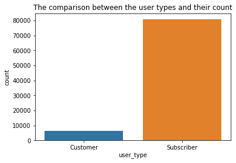

```python
sb.countplot(x='user_type', data=biketrip)
plt.title('The comparison between the user types and their count');
plt.show()
```

> **Observation:-** We can clearly observe from the above graph that the number of subscribers are very much than the number of customers which clearly shows that most of the users were subscribers and use the services regularly.

### Which age group used the services most?

> We will plot the age of the members with the number of users from that group and decide which age group was most active in using these services.

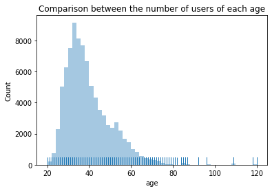

```python
sb.distplot(biketrip.age, kde=False, rug=True);
plt.ylabel('Count');
plt.title('Comparison between the number of users of each age');
```

## Bi-Variate Plots:

### Which type of user used the services for longer time?

> We will find the graph between the user types and the time duration for which the services were availed.

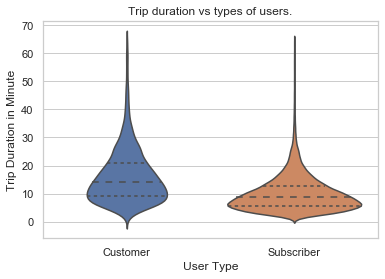

```python
sb.set(style="whitegrid")
sb.violinplot(data=biketrip, x='user_type', y='duration_minute', inner='quartile');
plt.xlabel('User Type');
plt.title('Trip duration vs types of users.');
plt.ylabel('Trip Duration in Minute');
```

> **Observation:-** We can clearly observe from the above graph that the trip duration was less for for the subscribers while with the increase with increase in duration time the Customer plot became more broad as compared to the subscriber plot.

> We also observed that the subscribers are using the sevices more for less duration while the customers are using them for more time as well.

### Which gender uses the services more and at which age?

> We will plot the violin plot between the age and the gender of the members to determine which gender was using the services at which age.

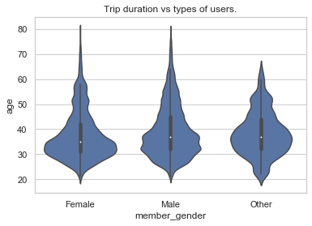

```python
data = biketrip[['member_gender', 'age']][biketrip.age < 80]
plt.title('Trip duration vs types of users.');
sb.violinplot(data=data, x='member_gender', y='age', color=sb.color_palette()[0]);
```

## Multi-Variate Plots:

### The age and gender distribution based on the user type:

> We will plot the gender of the gender vs age bar plot for both the user types to clearly see the data.

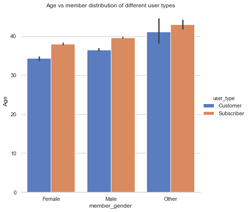

```python
g = sb.catplot(x="member_gender", y="age", hue="user_type", data=biketrip,
                height=6, kind="bar", palette="muted");
plt.title("Age vs member distribution of different user types");
g.despine(left=True)
g.set_ylabels("Age")
```

> **Observation:-** We can clearly see that the age of the subscribers are more than the customers for all the genders and the others category of gender use these services despite being more aged than the males and females.